# tugas 6 & 7

ayash

2026-09-30

```r
library(readxl)
library(forecast)
library(tseries)
```

```r
library(ggplot2)


data_excel <- read_excel("C:\\Users\\yasyah\\Downloads\\Copy of CPIAUCSL_PC1.xlsx", sheet = "Monthly")


str(data_excel)
```

```
## tibble [180 × 2] (S3: tbl_df/tbl/data.frame)
##  $ observation_date: POSIXct[1:180], format: "1948-01-01" "1948-02-01" ...
##  $ CPIAUCSL_PC1    : num [1:180] 10.24 9.48 6.82 8.27 9.38 ...
```

```r
head(data_excel)
```

```
## # A tibble: 6 × 2
##   observation_date    CPIAUCSL_PC1
##   <dttm>                     <dbl>
## 1 1948-01-01 00:00:00        10.2
## 2 1948-02-01 00:00:00         9.48
## 3 1948-03-01 00:00:00         6.82
## 4 1948-04-01 00:00:00         8.27
## 5 1948-05-01 00:00:00         9.38
## 6 1948-06-01 00:00:00         9.38
```

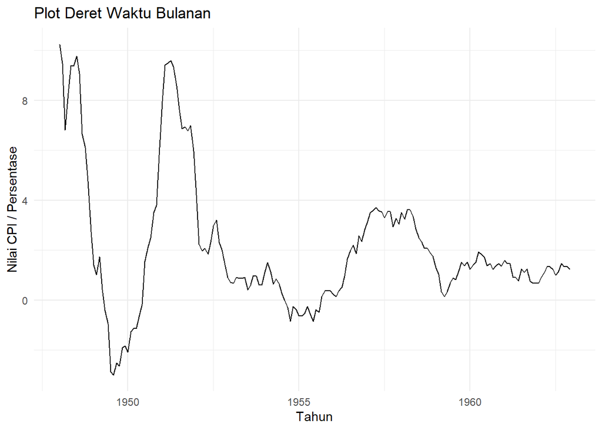

```r
# Konversi kolom data numerik ke objek time series (bulanan -> frequency = 12)
# Sesuaikan indeks kolom (misal kolom ke-2) dan tahun/bulan awal data Anda

ts_data <- ts(data_excel[[2]], start = c(1948, 1), frequency = 12)

# Plot deret waktu awal
autoplot(ts_data) +
  ggtitle("Plot Deret Waktu Bulanan") +
  xlab("Tahun") + ylab("Nilai CPI / Persentase") +
  theme_minimal()
```

```r
# Uji ADF pada data asli (level)
adf_test_level <- adf.test(ts_data, alternative = "stationary")
print(adf_test_level)
```

```
##
##  Augmented Dickey-Fuller Test
##
## data:  ts_data
## Dickey-Fuller = -4.2398, Lag order = 5, p-value = 0.01
## alternative hypothesis: stationary
```

Interpretasi dan Hipotesis Uji ADF:

Hipotesis Nol ($H_0$): Data tidak stasioner (memiliki unit root).

Hipotesis Alternatif ($H_1$): Data stasioner.

Kriteria Keputusan:

- Jika $p\text{-value} > 0,05$: Gagal tolak $H_0$ $\rightarrow$ Data tidak stasioner. Diperlukan proses diferensiasi (differencing).
- Jika $p\text{-value} \le 0,05$: Tolak $H_0$ $\rightarrow$ Data sudah stasioner pada level ($d = 0$).

Interpretasi: Karena $p\text{-value} = 0,01 \le 0,05$, keputusan uji statistik adalah Tolak $H_0$. Artinya, data deret waktu sudah stasioner pada tingkat dasar (level) tanpa memerlukan proses diferensiasi ($d = 0$).

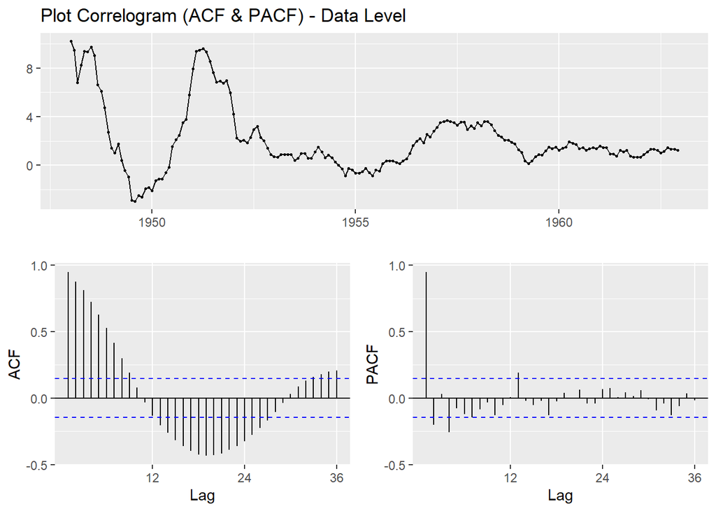

```r
ggtsdisplay(ts_data, main = "Plot Correlogram (ACF & PACF) - Data Level")
```

Interpretasi:

Plot ACF yang memotong batas signifikansi (cut-off) setelah lag tertentu mengindikasikan kandidat nilai $q$.

Plot PACF yang cut-off pada lag awal mengindikasikan kandidat nilai $p$.

```r
fit_arima <- auto.arima(ts_data,d = 0, stepwise = FALSE, approximation = FALSE, trace = TRUE)
```

```
##
##  ARIMA(0,0,0)            with zero mean     : 956.1187
##  ARIMA(0,0,0)            with non-zero mean : 875.1543
##  ARIMA(0,0,0)(0,0,1)[12] with zero mean     : 937.6764
##  ARIMA(0,0,0)(0,0,1)[12] with non-zero mean : 863.0124
##  ARIMA(0,0,0)(0,0,2)[12] with zero mean     : Inf
##  ARIMA(0,0,0)(0,0,2)[12] with non-zero mean : Inf
##  ARIMA(0,0,0)(1,0,0)[12] with zero mean     : 946.8665
##  ARIMA(0,0,0)(1,0,0)[12] with non-zero mean : 872.6997
##  ARIMA(0,0,0)(1,0,1)[12] with zero mean     : Inf
##  ARIMA(0,0,0)(1,0,1)[12] with non-zero mean : Inf
##  ARIMA(0,0,0)(1,0,2)[12] with zero mean     : Inf
##  ARIMA(0,0,0)(1,0,2)[12] with non-zero mean : Inf
##  ARIMA(0,0,0)(2,0,0)[12] with zero mean     : 948.6255
##  ARIMA(0,0,0)(2,0,0)[12] with non-zero mean : 842.3169
##  ARIMA(0,0,0)(2,0,1)[12] with zero mean     : Inf
##  ARIMA(0,0,0)(2,0,1)[12] with non-zero mean : 818.6565
##  ARIMA(0,0,0)(2,0,2)[12] with zero mean     : 924.6695
##  ARIMA(0,0,0)(2,0,2)[12] with non-zero mean : 820.7524
##  ARIMA(0,0,1)            with zero mean     : Inf
##  ARIMA(0,0,1)            with non-zero mean : Inf
##  ARIMA(0,0,1)(0,0,1)[12] with zero mean     : Inf
##  ARIMA(0,0,1)(0,0,1)[12] with non-zero mean : Inf
##  ARIMA(0,0,1)(0,0,2)[12] with zero mean     : Inf
##  ARIMA(0,0,1)(0,0,2)[12] with non-zero mean : Inf
##  ARIMA(0,0,1)(1,0,0)[12] with zero mean     : Inf
##  ARIMA(0,0,1)(1,0,0)[12] with non-zero mean : Inf
##  ARIMA(0,0,1)(1,0,1)[12] with zero mean     : Inf
##  ARIMA(0,0,1)(1,0,1)[12] with non-zero mean : Inf
##  ARIMA(0,0,1)(1,0,2)[12] with zero mean     : Inf
##  ARIMA(0,0,1)(1,0,2)[12] with non-zero mean : Inf
##  ARIMA(0,0,1)(2,0,0)[12] with zero mean     : Inf
##  ARIMA(0,0,1)(2,0,0)[12] with non-zero mean : Inf
##  ARIMA(0,0,1)(2,0,1)[12] with zero mean     : Inf
##  ARIMA(0,0,1)(2,0,1)[12] with non-zero mean : Inf
##  ARIMA(0,0,1)(2,0,2)[12] with zero mean     : Inf
##  ARIMA(0,0,1)(2,0,2)[12] with non-zero mean : Inf
##  ARIMA(0,0,2)            with zero mean     : 580.0878
##  ARIMA(0,0,2)            with non-zero mean : 527.5112
##  ARIMA(0,0,2)(0,0,1)[12] with zero mean     : 580.0937
```

[output cut: 142 more lines]

```
##  ARIMA(3,0,2)            with non-zero mean : Inf
##  ARIMA(4,0,0)            with zero mean     : 325.2125
##  ARIMA(4,0,0)            with non-zero mean : 323.5119
##  ARIMA(4,0,0)(0,0,1)[12] with zero mean     : Inf
##  ARIMA(4,0,0)(0,0,1)[12] with non-zero mean : Inf
##  ARIMA(4,0,0)(1,0,0)[12] with zero mean     : 277.711
##  ARIMA(4,0,0)(1,0,0)[12] with non-zero mean : 275.5395
##  ARIMA(4,0,1)            with zero mean     : 325.9324
##  ARIMA(4,0,1)            with non-zero mean : 318.2616
##  ARIMA(5,0,0)            with zero mean     : 325.9562
##  ARIMA(5,0,0)            with non-zero mean : 324.861
##
##
##
##  Best model: ARIMA(2,0,1)(0,0,2)[12] with non-zero mean
```

Parameter d = 0 ditetapkan pada fungsi auto.arima() berdasarkan hasil stasioneritas. Fungsi mengevaluasi berbagai kombinasi $ARIMA(p, 0, q)$ dan memilih model dengan nilai AICc (Akaike Information Criterion Corrected) terkecil.

```r
summary(fit_arima)
```

```
## Series: ts_data
## ARIMA(2,0,1)(0,0,2)[12] with non-zero mean
##
## Coefficients:
##          ar1      ar2      ma1     sma1    sma2    mean
##       1.8897  -0.8921  -0.6237  -1.4650  0.5349  2.0572
## s.e.  0.0763   0.0761   0.1382   0.0939  0.0978  0.3690
##
## sigma^2 = 0.1324:  log likelihood = -89.9
## AIC=193.8   AICc=194.45   BIC=216.15
##
## Training set error measures:
##                       ME      RMSE       MAE MPE MAPE      MASE       ACF1
## Training set 0.004834093 0.3577306 0.2581109 Inf  Inf 0.1002667 0.02786321
```

Interpretasi: Model dengan nilai AICc/BIC paling rendah memberikan keseimbangan paling optimal antara akurasi model dan efisiensi jumlah parameter.

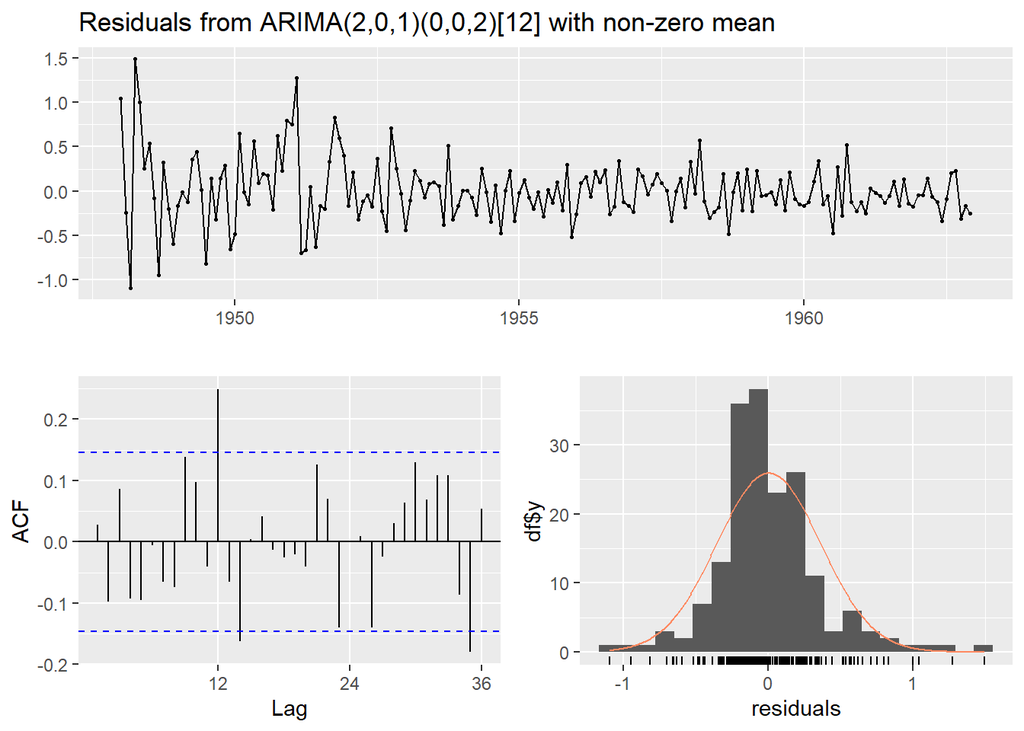

```
##
##  Ljung-Box test
##
## data:  Residuals from ARIMA(2,0,1)(0,0,2)[12] with non-zero mean
## Q* = 41.669, df = 19, p-value = 0.001964
##
## Model df: 5.   Total lags used: 24
```

```r
checkresiduals(fit_arima)
```

```r
box_test <- Box.test(residuals(fit_arima), lag = 12, type = "Ljung-Box")
print(box_test)
```

```
##
##  Box-Ljung test
##
## data:  residuals(fit_arima)
## X-squared = 26.249, df = 12, p-value = 0.009895
```

Uji Ljung-Box: Jika $p\text{-value} > 0,05$, maka $H_0$ (sisaan bersifat white noise) gagal ditolak. Ini menunjukkan tidak ada lagi pola autokorelasi yang tertinggal dalam sisaan.

Histogram Sisaan: Memastikan sisaan terdistribusi secara acak di sekitar nilai nol dan mendekati distribusi normal.

```r
ramalan <- forecast(fit_arima, h = 12)
print(ramalan)
```

```
##          Point Forecast      Lo 80    Hi 80       Lo 95    Hi 95
## Jan 1963      1.2162789  0.7494964 1.683061  0.50239662 1.930161
## Feb 1963      1.1338066  0.3809136 1.886700 -0.01764381 2.285257
## Mar 1963      0.9138548 -0.1142126 1.941922 -0.65843867 2.486148
## Apr 1963      0.9215789 -0.3785778 2.221736 -1.06683917 2.909997
## May 1963      1.0269451 -0.5427795 2.596670 -1.37374156 3.427632
## Jun 1963      1.4505682 -0.3853394 3.286476 -1.35721021 4.258347
## Jul 1963      1.6627426 -0.4348719 3.760357 -1.54528194 4.870767
## Aug 1963      1.5578130 -0.7960306 3.911657 -2.04208012 5.157706
## Sep 1963      1.1924295 -1.4113350 3.796194 -2.78968470 5.174544
## Oct 1963      1.6615979 -1.1851278 4.508323 -2.69209328 6.015289
## Nov 1963      1.9135018 -1.1687365 4.995740 -2.80037496 6.627379
## Dec 1963      2.3069905 -1.0029652 5.616946 -2.75514982 7.369131
```

point forecast : Nilai estimasi utama untuk peramalan bulanan ke depan.

LO/HI : Selang kepercayaan $80\%$ dan $95\%$. Mengindikasikan batas bawah dan atas nilai aktual yang diperkirakan terjadi pada masa depan.

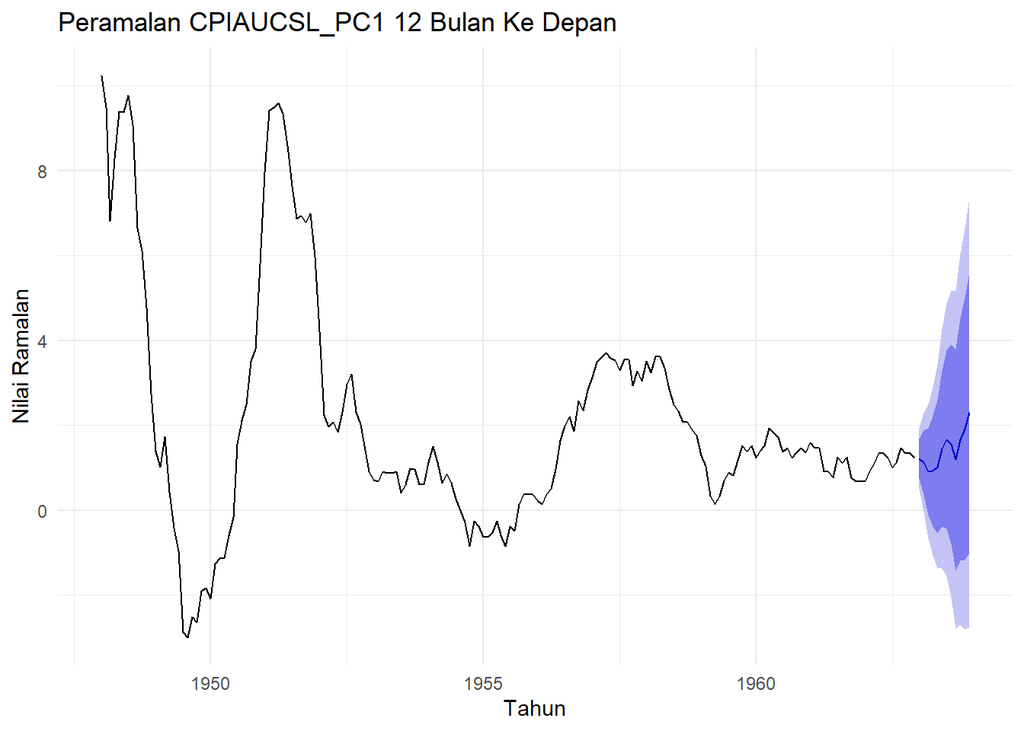

```r
autoplot(ramalan) +
  ggtitle("Peramalan CPIAUCSL_PC1 12 Bulan Ke Depan") +
  xlab("Tahun") + ylab("Nilai Ramalan") +
  theme_minimal()
```